# Wrangling Data Open Ended Assignment

Robert Thomas Kohn

9/30/25

# Option 1: Dealbreakers in Dating (Yes/No)

My question to explore is “What is the least attractive trait to someone looking for a relationship?” I anticipate that the ordering will be Personality, Tobacco,Political,Appearence, Dependent, Underplanner, Overplanner, Marijuana, Independent. I don’t know how to import a sketch to R.

I need to get all types of dealbreakers into a summarized format. I can do this with raw numbers as there is equal participants or as a percentage if I divide over n. I think in this case a percentage will serve to be more benefical as to most a random number of people who think these things is irrelevant. Seeing “x% of people find y to be the greatest dealbreaker” is much more impactful.

```r
library(readr)
DatingPreferencesBinary <- read_csv("DatingPreferencesBinary.csv")
head(DatingPreferencesBinary)
```

```
## # A tibble: 6 × 10
##   OpposingReligiousBeliefs OpposingPoliticalBeliefs UnpleasantAppearance
##   <chr>                    <chr>                    <chr>
## 1 No                       No                       Yes
## 2 Yes                      No                       No
## 3 No                       No                       Yes
## 4 Yes                      Yes                      No
## 5 Yes                      Yes                      No
## 6 Yes                      Yes                      No
## # ℹ 7 more variables: UnpleasantPersonality <chr>, TobaccoSmoker <chr>,
## #   MarijuanaSmoker <chr>, IndependantPerson <chr>, DependentPerson <chr>,
## #   OverPlanner <chr>, Underplanner <chr>
```

```r
summary(DatingPreferencesBinary)
```

```
##  OpposingReligiousBeliefs OpposingPoliticalBeliefs UnpleasantAppearance
##  Length:52                Length:52                Length:52
##  Class :character         Class :character         Class :character
##  Mode  :character         Mode  :character         Mode  :character
##  UnpleasantPersonality TobaccoSmoker      MarijuanaSmoker    IndependantPerson
##  Length:52             Length:52          Length:52          Length:52
##  Class :character      Class :character   Class :character   Class :character
##  Mode  :character      Mode  :character   Mode  :character   Mode  :character
##  DependentPerson    OverPlanner        Underplanner
##  Length:52          Length:52          Length:52
##  Class :character   Class :character   Class :character
##  Mode  :character   Mode  :character   Mode  :character
```

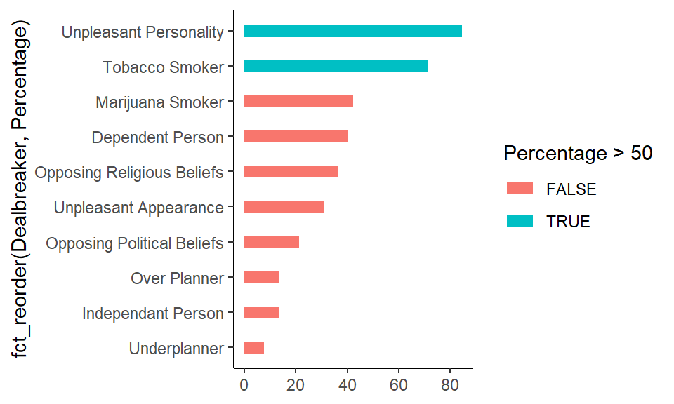

```r
dpc <- DatingPreferencesBinary %>% mutate(across(everything(), as.factor)) #Cleaning and Factor
dr<-dpc%>%summarise(across(everything(), ~sum(. == "Yes")/n() * 100))%>%pivot_longer(everything(), names_to = "Dealbreaker", values_to = "Percentage") #Basing on Percentage
dr <- dr %>% mutate(Dealbreaker = str_replace_all(Dealbreaker, pattern = "(?<=.)([A-Z])", replacement = " \\1")) #Fixing Camel Notation - GPT Assisted because I didn't want to do this part manually in the dataset.

gf_linerange(fct_reorder(Dealbreaker, Percentage) ~ 0 + Percentage, data = dr, size = 3, color = ~Percentage>50) # Base Graph
```

```r
head(dr)
```

```
## # A tibble: 6 × 2
##   Dealbreaker                Percentage
##   <chr>                           <dbl>
## 1 Opposing Religious Beliefs       36.5
## 2 Opposing Political Beliefs       21.2
## 3 Unpleasant Appearance            30.8
## 4 Unpleasant Personality           84.6
## 5 Tobacco Smoker                   71.2
## 6 Marijuana Smoker                 42.3
```

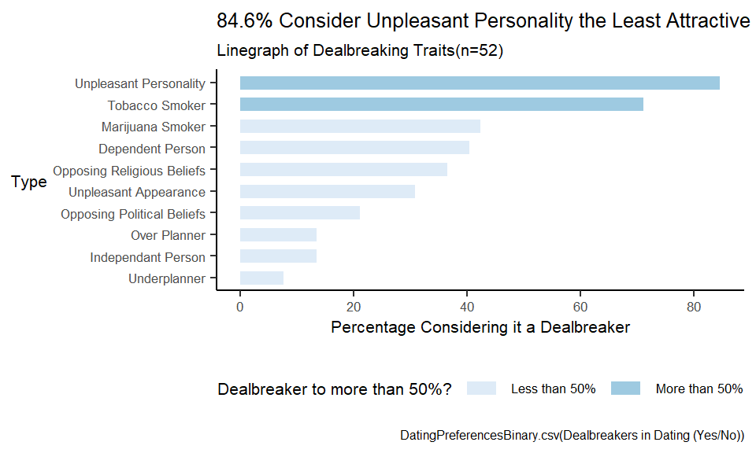

```r
gf_linerange(fct_reorder(Dealbreaker, Percentage) ~ 0 + Percentage, data = dr, size = 3, color = ~Percentage>50) %>%gf_refine(scale_color_brewer(palette = "Blues", labels = c("Less than 50%", "More than 50%"))) %>%gf_labs(x = "Percentage Considering it a Dealbreaker", y = "Type", title="84.6% Consider Unpleasant Personality the Least Attractive" , subtitle = "Linegraph of Dealbreaking Traits(n=52)" , caption = " DatingPreferencesBinary.csv(Dealbreakers in Dating (Yes/No))",color = "Dealbreaker to more than 50%?")%>%gf_theme(legend.position = "bottom",text = element_text(size = 8),axis.title.y = element_text(angle = 0, vjust = 0.5),plot.caption = element_text(size = 6)) # Revised Graph
```

I hate wrangling data in R so much. I am a spreadsheet merchant outside of this class and so having to wrangle things which are a small update is tedious at times but I digress. Trying to think about modifying columns in R to get what I want was a little troublesome for me at first until I realized I can effectively make this just like baseball but with a little spicing it up. There’s a lot of ways they could have simplified this off rip but I wonder if you could do a chi squared type test with this for some experiment. I think having only binary options within these categoricals made things slightly difficult too. I think what I would love to do would be making a heat map of these but I considered that too frustrating.

In my revised graph, I improved the legend so it has useful descriptors and moved it to the bottom. I also color coded it in a nicer way. Further, I also labeled the axes and added a caption. I thought with the subtitle including the n could be useful too.